# dataVisualization

Octavio Mesner

12/4/2020

## Data Visualization

- Visualizations can make understanding easier and faster (with a description)
- R and python make it very easy to generate some graphics
  - plots associated with models (glmnet, survival, twang)
- often these off-the-shelf graphics will not be publication ready

```r
# install.packages("glmnet", repos = "http://cran.us.r-project.org") # only need 1st time
library(glmnet)
```

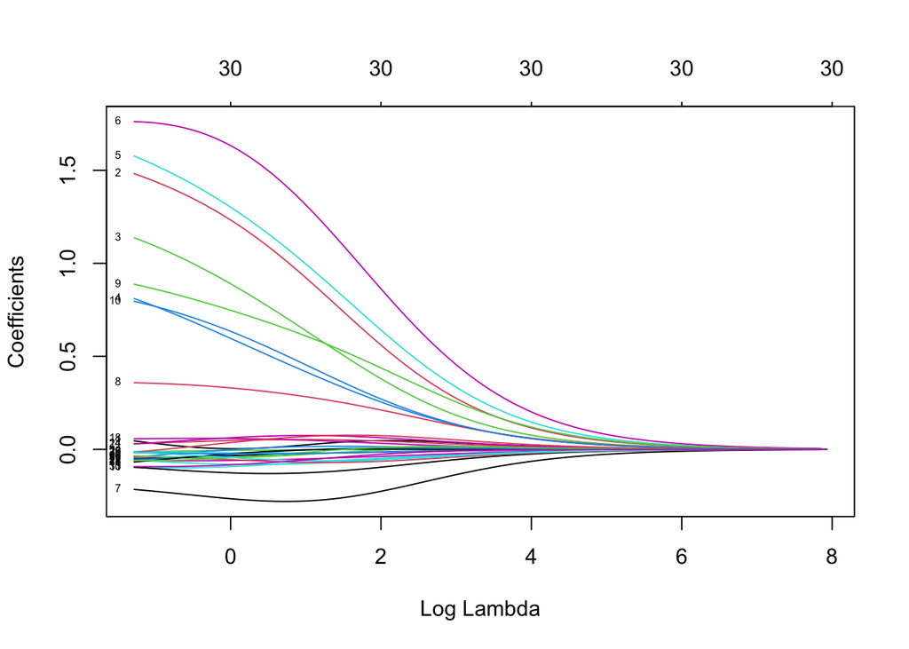

```r
design_mat <- cbind(active_x, null_x) # glmnet only takes matrices, not dataframes
l2_fit <- glmnet(design_mat, y, family="gaussian", alpha=0) # alpha = 0 gives Ridge regression
plot(l2_fit, xvar='lambda', label=TRUE)
```

```r
library(survival)
library(ggfortify)
```

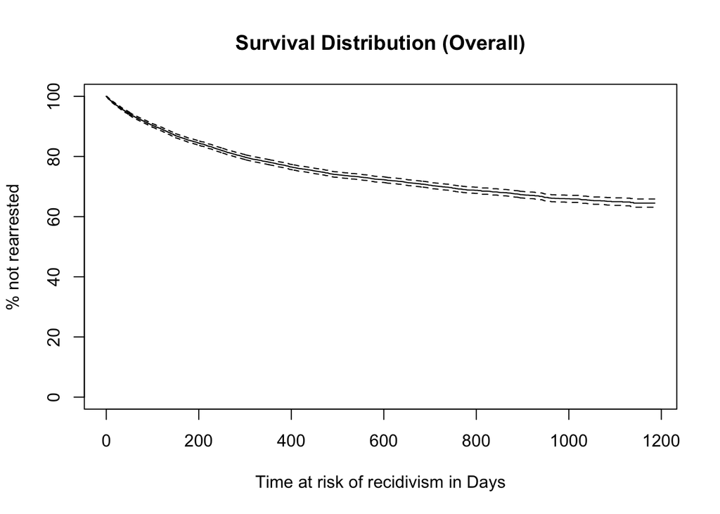

```r
dat <- read.csv(url('https://raw.githubusercontent.com/propublica/compas-analysis/master/cox-parsed.csv'))
dat2 <- dat[dat$end > dat$start,]
dat3 <- dat2[!duplicated(dat2$id),]
ph <- dat3[!is.na(dat3$decile_score),]
ph$t_atrisk <- ph$end - ph$start

survobj <- with(ph, Surv(t_atrisk, event))
fit0 <- survfit(survobj~1, data=ph)

plot(fit0, xlab="Time at risk of recidivism in Days",
 ylab="% not rearrested", yscale=100,
 main ="Survival Distribution (Overall)")
```

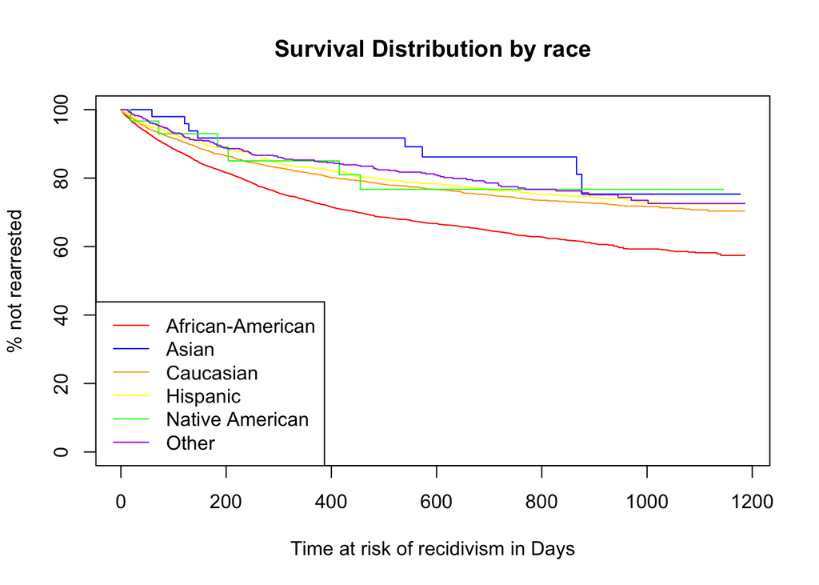

```r
fitr <- survfit(survobj~race, data=ph)
plot(fitr, xlab="Time at risk of recidivism in Days",
 ylab="% not rearrested", yscale=100,
 main="Survival Distribution by race",
 col = c('red', 'blue', 'orange', 'yellow', 'green', 'purple'))
legend('bottomleft', legend=levels(as.factor(ph$race)), col = c('red', 'blue', 'orange', 'yellow', 'green', 'purple'), lty=1)
```

*Software packages*

- R
  - Base R is very flexible and customizable, can take a lot of code for publication ready graphics
  - ggplot can make very nice plots with few lines of code

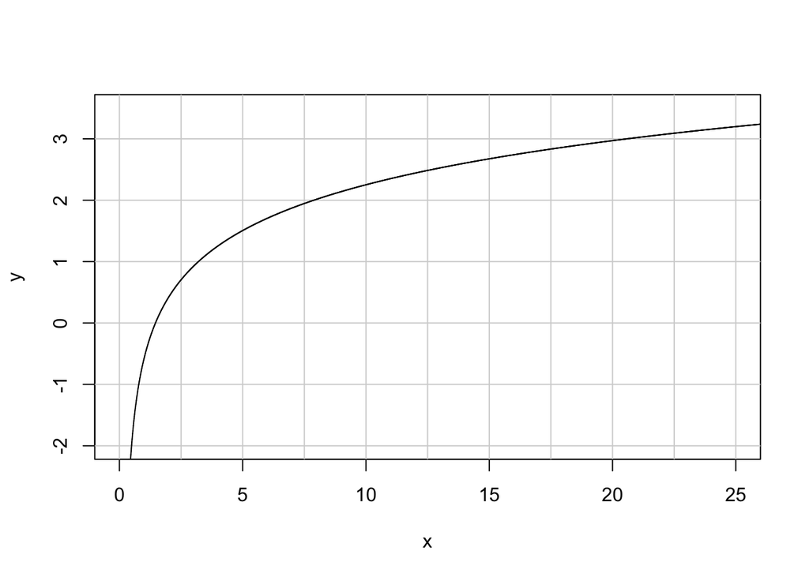

```r
# digamma plot
x <- seq(0.1, 30, by=0.0001)
ydig <- digamma(x)

plot(0,0, type='n', xlim=c(0,25), ylim=c(-2,3.5), xlab="x", ylab="y")
vlines = seq(0,25, by=2.5)
abline(v=vlines, col='lightgray')
hlines = seq(-2,10, by=1)
abline(h=hlines, col='lightgray')
lines(x,ydig, type='l', xlab="x", ylab="y")
```

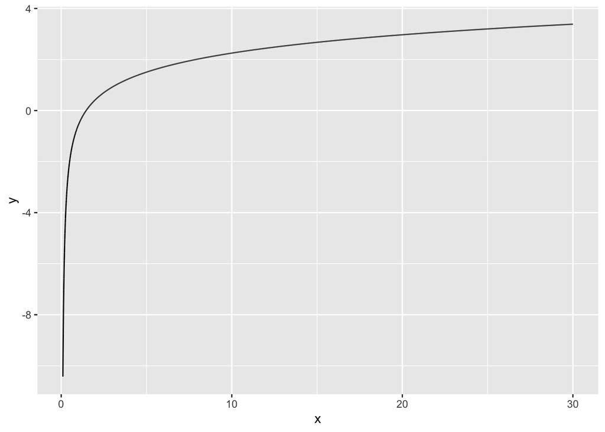

```r
dat <- data.frame(x,ydig)
ggplot(dat, aes(x,ydig)) + geom_line() + ylab('y')
```

- Python
  - Matplotlib is also flexible and customizable, but can take a lot of code
  - Seaborn might be closer to ggplot
  - Couldn’t get python working in Rmarkdown…
  - [histgrams in seaborn](https://seaborn.pydata.org/tutorial/distributions.html)
  - [histograms in matplotlib](https://seaborn.pydata.org/tutorial/distributions.html)
- Latex
  - tikz (I think) makes the most professional-looking graphics but can be a time sink
  - there are many libraries of code for tikz
  - [tikz statsitics examples](https://texample.net/tikz/examples/area/statistics/)

*General Advice*

- Graphics and time
  - Most graphics improve with time spend working on them
  - lower quality graphics can be fast
  - it’s easy to get tunnel vision and spend far too much time on perfect graphics
  - it’s ok to barrow as long as you give credit (pay attention to copyright for publications)
- Level of detail
  - too much or too little can both be bad
  - graphics should be used to communicate ideas quickly
  - will depend on audience
- Color
  - Typically want colors that stand out and are easy to distinguish from each other
  - More lines/curves means more more colors (usually) but harder to distinguish more colors
  - gray is less noticeable, sometimes you want that